# Сеетевые технологии

## Настройка DHCP в случае IPv6

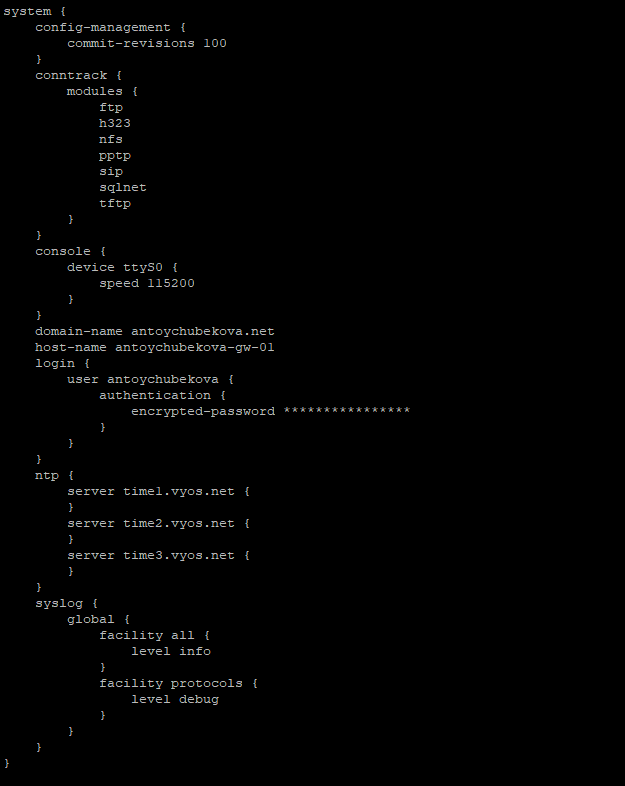

Сохранение и конфигурация

## Настройка DHCP в случае IPv6

На узле PC2 проверим настройки сети. На ПК2 настроены два сетевых интерфейса: eth0 с глобальным IPv6-адресом 2000::3c40:8bff:fece:ad0a и локальным fe80::3c40:8bff:fece:ad0a, а также eth1 с локальным IPv6-адресом fe80::b0ee:9cff:fea5:a8. Интерфейс lo настроен для loopback (127.0.0.1 и ::1).

## Настройка DHCP в случае IPv6

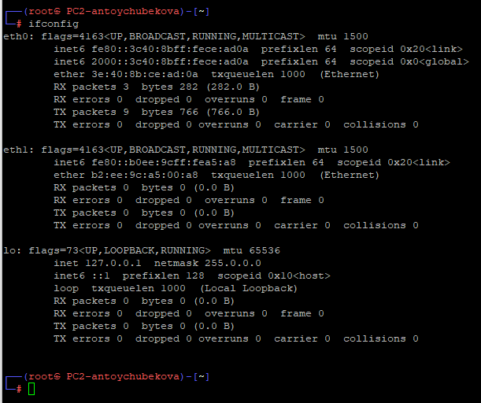

Настройка сети

## Настройка DHCP в случае IPv6

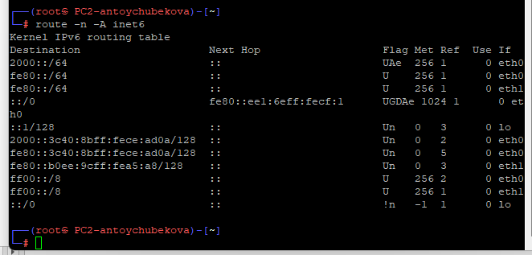

Настройка сети

## Настройка DHCP в случае IPv6

На узле PC2 пропингуем маршрутизатор. Мы видим, что все правильно обрабатывается.

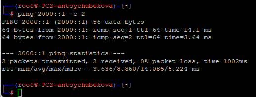

## Настройка DHCP в случае IPv6

На узле PC2 проверим настройки DNS.

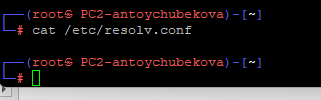

Настройка DNS

## Настройка DHCP в случае IPv6

На узле PC2 получим адрес по DHCPv6. Здесь опция -6 указывает на использование протокола DHCPv6, опция -S — на запрос только информации DHCPv6, но не адреса, опция -v — на вывод на экран подробной информации.

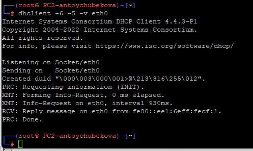

Настройка DNS

## Настройка DHCP в случае IPv6

Вновь пропингуем от узла PC2 маршрутизатор, проверим настройки DNS. Мы видим имя домена и его IPv6.

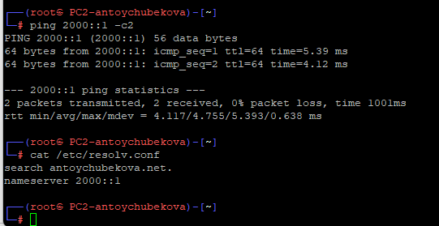

Настройки DNS и проверка доступности

## Настройка DHCP в случае IPv6

На маршрутизаторе посмотрим статистику DHCP-сервера и выданные адреса.

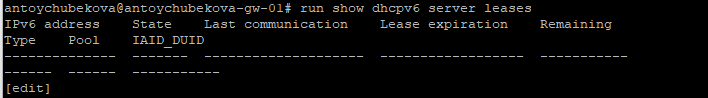

Статистика DHCP

## Настройка DHCP в случае IPv6

Далее просмотрим захваченный трафик.

[figure not shown]

DHCP-пакет

## Настройка DHCP в случае IPv6

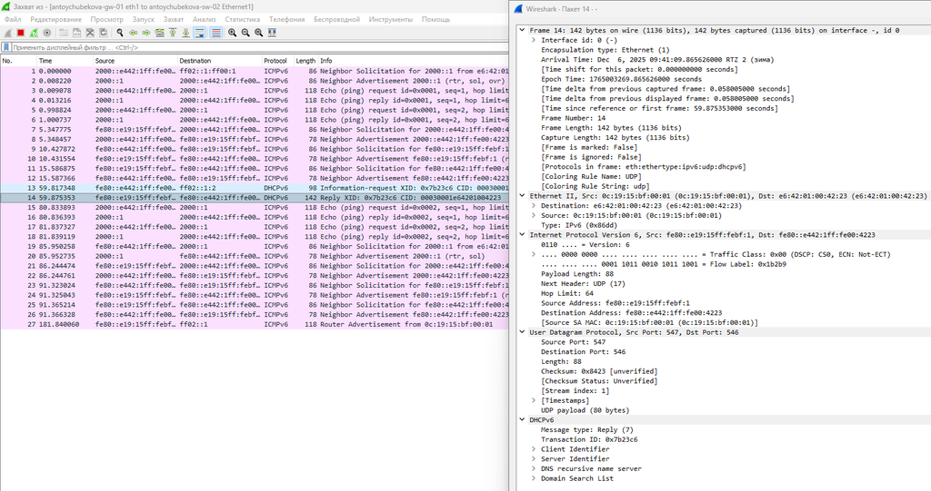

DHCP-пакет

## Настройка DHCP в случае IPv6

[figure not shown]

Трафик

## Настройка DHCP в случае IPv6

На маршрутизаторе настроим DHCPv6 с отслеживанием состояния. На интерфейсе eth2 маршрутизатора настроим объявления о маршрутизаторах. Опция managed-flag означает, что хосты использует администрируемый (отслеживающий состояние) протокол для автоматической настройки адресов в дополнение к любым адресам, автоматически настраиваемым с помощью SLAAC.

## Настройка DHCP в случае IPv6

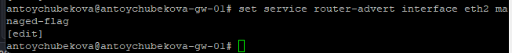

Настройка объявление о маршрутизаторах

## Настройка DHCP в случае IPv6

Добавим конфигурацию DHCP-сервера на маршрутизаторе. Создаем разделяемая сеть (shared-network-name) с названием username, подсеть (subnet) с адресом 2001::/64, задаем диапазон адресов (range) с именем hosts, содержащий адреса 2001::100 – 2001::199.

На маршрутизаторе посмотрим статистику DHCP-сервера и выданные адреса.

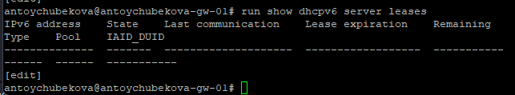

Статистика DHCP-сервера

## Настройка DHCP в случае IPv6

Подключимся к узлу PC3 и проверим настройки сети.

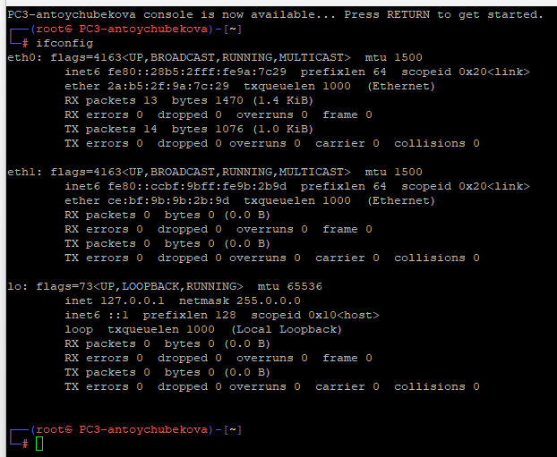

Настройка сети

## Настройка DHCP в случае IPv6

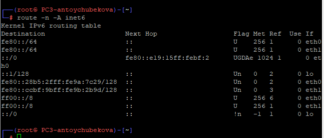

Настройка сети

## Настройка DHCP в случае IPv6

На узле PC3 проверим настройки DNS.

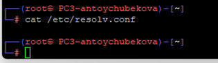

Настройка DNS

## Настройка DHCP в случае IPv6

На узле PC3 получите адрес по DHCPv.

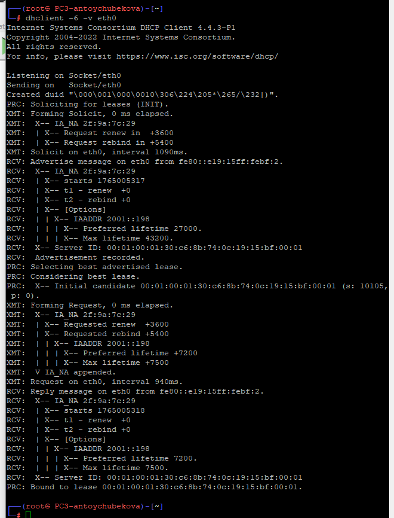

Получение адреса по DHCPv

## Настройка DHCP в случае IPv6

Вновь на узле PC3 проверим настройки сети, пропингуем маршрутизатор, проверьте настройки DNS.

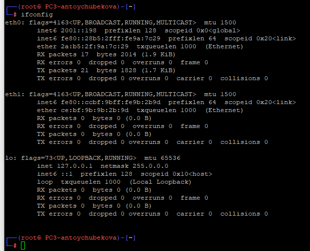

Настройка сети

## Настройка DHCP в случае IPv6

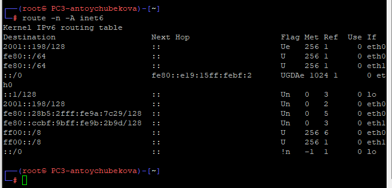

Настройка сети

## Настройка DHCP в случае IPv6

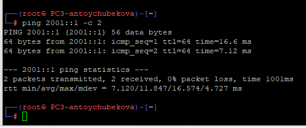

Проверка досткпности

## Настройка DHCP в случае IPv6

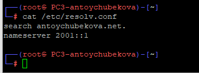

Настройка DNS

## Настройка DHCP в случае IPv6

На маршрутизаторе посмотриv статистику DHCP-сервера и выданные адреса.

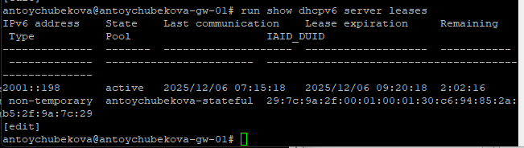

Статистика DHCP-сервера

## Настройка DHCP в случае IPv6

Далее посмотри захваченный трафик по DHCPv6.

[figure not shown]

Трафик

# Выводы

## Выводы

В ходе выполнения лабораторной работы №7 я получила навыки настройки службы DHCP на сетевом оборудовании для распределения адресов IPv4 и IPv6.